# F1. Foundations in probability theory

Author

Ullrika Sahlin

# Random experiment

A “trial” for which the outcome is unknown

# Outcome

A result of a random experiment $\omega$

# Outcome space

All possible outcomes $\Omega$

# Event

One or several outcomes (a subset of the outcome space) e.g. A, B or C

**Example: Dice**

A random experiment: Throw of a dice

Outcome space: $\{1, 2, 3, 4, 5, 6\}$

Examples of events:

A = “Get a 3” $\{3\}$

B = “Get an even number” $\{2, 4, 6\}$

C = “Get a two or a five” $\{2, 5\}$

**Example: People with allergies**

Random experiment: Proportion of individuals with allergies amoung day care children

Outcome space: Infinitely possible outcomes in the interval $[0,100]$

Example of event: A = “Proportion children with allergies are higher than 6 %”

**Example: Waiting time**

Random experiment: Waiting time in a queue in a shop (in minutes)

Outcome space: All times in $(0,\infty)$

Example of event: Q = “A person must wait at least one minute”

# disjoint events

A and B are disjoint events if they cannot occur at the same time.

$A \cap B = \emptyset$

# Probability

- Classical probability: number of favourable outcomes over the number of possible outcomes
- Relative frequency: how often an outcome occurs in an infinite sequences of random independent trials
- Subjective probability: someone’s uncertainty/certainty about a statement

# Probability rules

- Axiomatic probability: a mathematical measure describing random experiments.

The probability for event A is written $P(A)$

1. $0\leq P(A) \leq 1$
2. $P(\Omega)=1$
3. If $A_1$ and $A_2$ are disjoint, then $P(A_1\cup A_2) = P(A_1) + P(A_2)$

## Union and intersection

Intersection: $A \cap B$ means **A and B**

Union: $A \cup B$ means **A or B**

## Complementary event

$P(A) + P(\bar{A}) = 1$

$P(\bar{A}) = 1 - P(A)$

**Example: Complementary event**

A = “Dice shows six dots”

$\bar{A}$ = “Dice **does not** show six dots”

$P(A) = \frac{1}{6}$

$P(\bar{A}) = 1 - P(A) = 1 - \frac{1}{6} = \frac{5}{6}$

# The additive theorem of probability

$P(A \cup B) = P(A) + P(B) - P(A \cap B)$

Note that $P(\emptyset)=0$, and therefore the last term disappears when A and B are disjoint.

# Independent events

If A and B are independent, then $P(A \cap B) = P(A)\cdot P(B)$

**Example: Independent tosses a dice**

A dice is thrown two times

A = “First throw is a two” B = “Second throw is a three”

A and B are independent

$P(A \cap B) = P(A) \cdot P(B) = \frac{1}{6}\cdot\frac{1}{6} = \frac{1}{36}$

**Independent and disjoint events are different things!**

Independence $P(A \cap B) = P(A) \cdot P(B)$

disjoint $P(A \cap B) = 0$

**Example. At least one**

We know that 40% in a patient population has high blood pressure. We choose two patients at random.

A = “Person 1 has high blood pressure” B = “Person 2 has high blood pressure”

What is the probability that **at least one** of the patients has a high blood pressure, i.e. $P(A \cup B)$?

From the information we know that P(A) = P(B) = 0.4

We can also assume that the events A and B are independent.

$$\begin{split} & P(A \cup B) = P(A) + P(B) - P(A \cap B) = \\ & P(A) + P(B) - P(A)\cdot P(B) = \\ & 0.4 + 0.4 - 0.4\cdot 0.4 = 0.64 \end{split}$$

**Example. Exactly one**

What is the probability that **exactly one** of the patients has a high blood pressure, i.e. $P(A \cup B)-P(A \cap B)$?

$P(A \cup B) -P(A \cap B) = P(A) + P(B) - 2P(A \cap B) =$

$P(A) + P(B) - P(A)\cdot P(B) = 0.4 + 0.4 - 2\cdot 0.4\cdot 0.4 = 0.48$

**Example. Blood transfusion**

In a country the probability to be infected by HIV by blood transfusion is 1%. Assume that a person has received blood transfusion 20 times. What is the probability that the person has been infected by HIV in this way?

Let $A_i$ be the event “infected at transfusion i”, where i = 1 to 20.

From the information we know that $P(A_i)=0.01$.

The probability we seek is $P(A_1 \cup A_2 \cup ... \cup A_20)$ This can also be written as $1 - P(\bar{A_1}\cap\bar{A_2}\cap...\cap\bar{A_{20}})$

If we assume that the events are independent, then

$1-P(\bar{A_1})P(\bar{A_2})...P(\bar{A}_{20}) = 1 - (1-0.01)^{20} = 0.182$

# Conditional probability

If we know that B has occured - what is the probability that A will happen?

$P(A|B) = \frac{P(A \cap B)}{P(B)}$

**Example: Play online poker**

1000 randomly chosen persons were asked if they ever have played online poker and if they have economic problems. This is the result.

|  | Does not play | Play |
| --- | --- | --- |
| Has economic problems | 300 | 90 |
| Do not have economical problems | 500 | 110 |

1. What is the probability that a randomly chosen person has economical problems?

Let us introduced some notations: E = “has economical problems” and S = “play”

$P(E) = \frac{300 + 90}{1000} = 0.39$

2. What is the probability that a person that play has economical problems?

$P(E|S) = \frac{90}{90+110} = 0.45$

**Example**

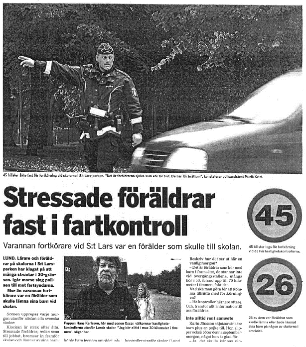

At the check, 45 drivers were caught speeding. 26 of them were parents who were picking up their children.

Police officer Patrik’s conclusion is simple and clear: ‘It’s the parents themselves who drive the fastest.’

Is the policeman correct in his conclusion?

Let’s introduce some notation:

Event F is ‘a parent is the driver’

Event K is ‘the driver is speeding’

We have information about P(F|K)

Officer Patrik makes a statement about P(K|F). To say something about how likely it is that a parent is speeding, we need to know how common speeding drivers are P(K) and how many of the drivers are parents P(F).

Patrik has made a hasty conclusion based on the information he has.

**One cannot simply swap them**

$P(A|B) \neq P(B|A)$

# The multiplication theorem of probability

For two events A and B the following holds

$P(A \cap B) = P(A|B) \cdot P(B)$

$P(B \cap A) = P(B|A) \cdot P(A)$

# Bayes’ theorem (Bayes’ rule)

From the multiplication theorem we get

$\Rightarrow \frac{P(A|B) \cdot P(B)}{P(B)} = \frac{P(B|A) \cdot P(A)}{P(B)}$

$\Rightarrow P(A|B) = \frac{P(B|A) \cdot P(A)}{P(B)}$

# The law of total probability

$H_1$, $H_2$, $H_3$ and $H_4$ are disjoint events covering the whole outcome space $\Omega$.

Then, for event $A$

$P(A)=P(A|H_1)\cdot P(H_1) + P(A|H_2)\cdot P(H_2) +$

$P(A|H_3)\cdot P(H_3) + P(A|H_4)\cdot P(H_4)$

**Exam question**

“To detect uterine cancer at an early stage, regular cell samples from the cervix are examined. In such a test, it is known that”

P(test positive | cancer) = 0.8

P(test positive | no cancer) = 0.1

Assume that there are 10 out of 10,000 women who have this type of cancer. What is the probability, if we randomly select and test a woman, that her test shows positive?

We introduce a simpler notation.

$P(+ | c) = 0.8$

$P(+ | \bar{c}) = 0.1$

From the information we know that $P(c) = 10/10000 = 0.001$

The law of total probability makes it possible to calculated the probability that is asked for as

$P(+) = P(+|c)\cdot P(c) + P(+|\bar{c})\cdot P(\bar{c}) = 0.8 \cdot 0.001 + 0.1 \cdot (1-0.001) = 0.1007$

**Example. Complementary events**

The events A and B are independent with P(A) = 0.1 and P(B) = 0.05

Calculate $P(\bar{A}\cap \bar{B})$?

$P(\bar{A}\cap \bar{B}) = P(\bar{A}) \cdot P(\bar{B}) =$

$(1-P(A)) \cdot (1-P(B)) = (1-0.1)\cdot (1-0.05)=0.9\cdot 0.95 = 0.855$

**Example. Family dinner**

The families A, B and C are invited for dinner. The probability that they will come are the following: P(A) = 0.8, P(B) = 0.6 och P(C) = 0.9. They come independent of each other.

What is the probability that

1. All will come? $P(A \cap B \cap C)=P(A) \cdot P(B) \cdot P(C)$
2. No one will come? $P(\bar{A} \cap \bar{B} \cap \bar{C})=(1-P(A)) \cdot (1-P(B)) \cdot (1-P(C))$
3. At least one will come? $P(\text{at least one})=1-P(\text{no one}) = 1 - P(\bar{A} \cap \bar{B} \cap \bar{C})$

# Combinatorics

How to work with combinations, permutations and countable sequences.

**Example: In how many ways can we order the letters A, B and C?**

ABC ACB BAC BCA CAB CBA

$3 \cdot 2 \cdot 1 = 6$

n-fakultet är $n! = n\cdot (n-1) \cdot (n-2) \cdot ... \cdot 2 \cdot 1$

It has been decided that $0!=1$

**Example: In how many ways can one shuffle a deck of cards?**

$52!$

Sometimes you are interested to calculate in how many ways one can choose k elements from n elements. The order does not matter.

$\binom{n}{k} = \frac{n!}{k!(n-k)!}$

**Example: In how many ways can you choose 5 cards?**

$\binom{52}{5} = \frac{52!}{5!47!}$

**Example: In how many ways can you get 10 correct answers on a quiz with 13 questions?**

$\binom{13}{10} = \frac{13!}{10!3!} = 286$